[figure not shown]

[figure not shown]

[figure not shown]

# Model fit

### Assumption checks

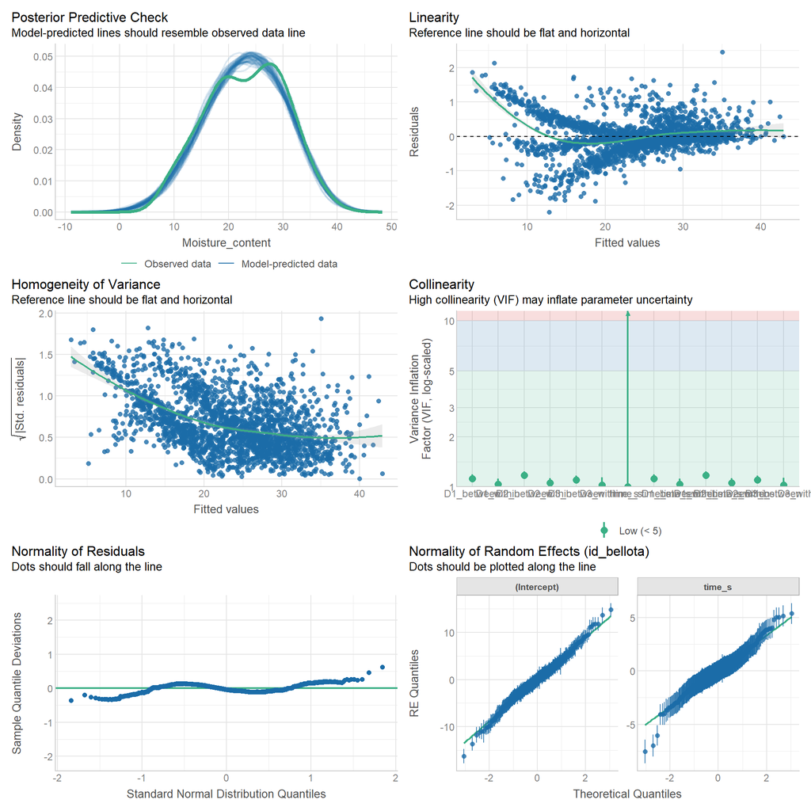

### Indices of model fit

| Metric | Value |
| --- | --- |
| AIC | 8062.7 |
| AICc | 8063.0 |
| BIC | 8165.5 |
| R2 (cond.) | 0.99 |
| R2 (marg.) | 0.57 |
| ICC | 0.98 |
| RMSE | 0.52 |
| Sigma | 0.66 |

For interpretation of performance metrics, please refer to [this documentation](https://easystats.github.io/performance/reference/model_performance.html).

# Parameter estimates

### Plot

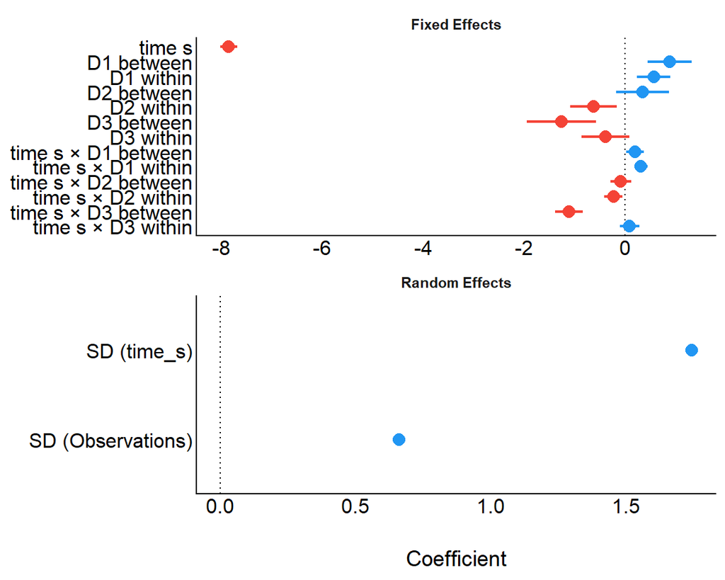

### Tabular summary

Fixed Effects

| Parameter | Coefficient | SE | 95% CI | z | p |
| --- | --- | --- | --- | --- | --- |
| (Intercept) | 29.67 | 0.22 | (29.24, 30.09) | 137.16 | < .001 |
| time s | -7.86 | 0.09 | (-8.03, -7.69) | -90.35 | < .001 |
| D1 between | 0.88 | 0.23 | (0.44, 1.32) | 3.91 | < .001 |
| D1 within | 0.56 | 0.17 | (0.24, 0.89) | 3.39 | < .001 |
| D2 between | 0.35 | 0.27 | (-0.18, 0.87) | 1.30 | 0.193 |
| D2 within | -0.63 | 0.23 | (-1.09, -0.17) | -2.68 | 0.007 |
| D3 between | -1.26 | 0.35 | (-1.95, -0.58) | -3.61 | < .001 |
| D3 within | -0.40 | 0.24 | (-0.87, 0.08) | -1.64 | 0.101 |
| time s × D1 between | 0.20 | 0.09 | (0.02, 0.37) | 2.16 | 0.031 |
| time s × D1 within | 0.31 | 0.07 | (0.18, 0.44) | 4.61 | < .001 |
| time s × D2 between | -0.09 | 0.11 | (-0.30, 0.12) | -0.81 | 0.421 |
| time s × D2 within | -0.23 | 0.09 | (-0.42, -0.05) | -2.48 | 0.013 |
| time s × D3 between | -1.12 | 0.14 | (-1.39, -0.84) | -7.96 | < .001 |
| time s × D3 within | 0.09 | 0.10 | (-0.10, 0.28) | 0.89 | 0.371 |

Random Effects

| Parameter | Coefficient |
| --- | --- |
| SD (Intercept: id_bellota) | 4.46 |
| SD (time_s: id_bellota) | 1.74 |
| Cor (Intercept~time_s: id_bellota) | -3.61e-03 |
| SD (Residual) | 0.66 |

To find out more about table summary options, please refer to [this documentation](https://easystats.github.io/parameters/reference/model_parameters.html).

# Predicted Values

### Plot

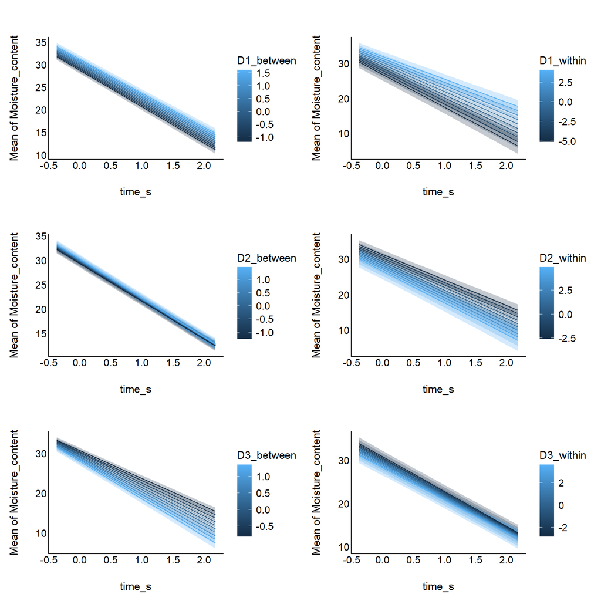

### Tabular summary

Estimated Marginal Means

| time_s | D1_between | Mean | SE | 95% CI | z |
| --- | --- | --- | --- | --- | --- |
| -0.38 | -1.19 | 31.72 | 0.35 | (31.03, 32.40) | 91.08 |
| -0.09 | -1.19 | 29.43 | 0.34 | (28.76, 30.11) | 85.66 |
| 0.19 | -1.19 | 27.14 | 0.34 | (26.47, 27.81) | 79.04 |
| 0.48 | -1.19 | 24.85 | 0.35 | (24.17, 25.54) | 71.50 |
| 0.76 | -1.19 | 22.56 | 0.36 | (21.86, 23.26) | 63.34 |
| 1.04 | -1.19 | 20.28 | 0.37 | (19.56, 21.00) | 55.00 |
| 1.33 | -1.19 | 17.99 | 0.38 | (17.24, 18.75) | 46.76 |
| 1.61 | -1.19 | 15.70 | 0.40 | (14.91, 16.49) | 38.84 |
| 1.90 | -1.19 | 13.42 | 0.43 | (12.58, 14.25) | 31.48 |
| 2.18 | -1.19 | 11.12 | 0.45 | (10.24, 12.01) | 24.68 |
| -0.38 | -0.88 | 31.97 | 0.30 | (31.39, 32.55) | 107.84 |
| -0.09 | -0.88 | 29.70 | 0.29 | (29.13, 30.27) | 101.54 |
| 0.19 | -0.88 | 27.42 | 0.29 | (26.85, 28.00) | 93.82 |
| 0.48 | -0.88 | 25.16 | 0.30 | (24.58, 25.74) | 85.01 |
| 0.76 | -0.88 | 22.88 | 0.30 | (22.29, 23.48) | 75.46 |
| 1.04 | -0.88 | 20.62 | 0.31 | (20.00, 21.23) | 65.67 |
| 1.33 | -0.88 | 18.35 | 0.33 | (17.71, 18.99) | 56.00 |
| 1.61 | -0.88 | 16.07 | 0.34 | (15.40, 16.75) | 46.71 |
| 1.90 | -0.88 | 13.81 | 0.36 | (13.09, 14.52) | 38.05 |
| 2.18 | -0.88 | 11.53 | 0.38 | (10.78, 12.28) | 30.05 |
| -0.38 | -0.57 | 32.22 | 0.25 | (31.72, 32.72) | 126.80 |
| -0.09 | -0.57 | 29.97 | 0.25 | (29.48, 30.46) | 119.53 |
| 0.19 | -0.57 | 27.71 | 0.25 | (27.22, 28.20) | 110.59 |
| 0.48 | -0.57 | 25.46 | 0.25 | (24.96, 25.96) | 100.37 |
| 0.76 | -0.57 | 23.20 | 0.26 | (22.69, 23.71) | 89.27 |
| 1.04 | -0.57 | 20.95 | 0.27 | (20.43, 21.48) | 77.87 |
| 1.33 | -0.57 | 18.70 | 0.28 | (18.15, 19.25) | 66.60 |
| 1.61 | -0.57 | 16.45 | 0.29 | (15.87, 17.02) | 55.76 |
| 1.90 | -0.57 | 14.20 | 0.31 | (13.59, 14.81) | 45.64 |
| 2.18 | -0.57 | 11.94 | 0.33 | (11.29, 12.58) | 36.30 |

[output cut: 70 more lines]

*Variable predicted: Moisture_content; Predictors modulated: time_s, D1_between; Predictors averaged: D1_within (2.4e-18), D2_between (0.02), D2_within (-1.5e-17), D3_between (-0.045), D3_within (4.5e-18), id_bellota*

Estimated Marginal Means

| time_s | D1_within | Mean | SE | 95% CI | z |
| --- | --- | --- | --- | --- | --- |
| -0.38 | -5.11 | 30.38 | 0.89 | (28.63, 32.12) | 34.14 |
| -0.09 | -5.11 | 27.71 | 0.88 | (25.99, 29.43) | 31.56 |
| 0.19 | -5.11 | 25.03 | 0.88 | (23.32, 26.75) | 28.53 |
| 0.48 | -5.11 | 22.37 | 0.89 | (20.63, 24.11) | 25.18 |
| 0.76 | -5.11 | 19.69 | 0.91 | (17.91, 21.48) | 21.64 |
| 1.04 | -5.11 | 17.02 | 0.94 | (15.18, 18.87) | 18.07 |
| 1.33 | -5.11 | 14.36 | 0.98 | (12.43, 16.28) | 14.60 |
| 1.61 | -5.11 | 11.68 | 1.03 | ( 9.66, 13.71) | 11.31 |
| 1.90 | -5.11 | 9.01 | 1.09 | ( 6.88, 11.15) | 8.28 |
| 2.18 | -5.11 | 6.34 | 1.15 | ( 4.08, 8.60) | 5.50 |
| -0.38 | -4.09 | 30.83 | 0.72 | (29.41, 32.25) | 42.56 |
| -0.09 | -4.09 | 28.26 | 0.71 | (26.86, 29.66) | 39.54 |
| 0.19 | -4.09 | 25.67 | 0.71 | (24.27, 27.07) | 35.94 |
| 0.48 | -4.09 | 23.09 | 0.72 | (21.67, 24.51) | 31.94 |
| 0.76 | -4.09 | 20.51 | 0.74 | (19.05, 21.96) | 27.68 |
| 1.04 | -4.09 | 17.93 | 0.77 | (16.42, 19.43) | 23.38 |
| 1.33 | -4.09 | 15.35 | 0.80 | (13.78, 16.92) | 19.18 |
| 1.61 | -4.09 | 12.76 | 0.84 | (11.12, 14.41) | 15.18 |
| 1.90 | -4.09 | 10.19 | 0.89 | ( 8.45, 11.92) | 11.49 |
| 2.18 | -4.09 | 7.60 | 0.94 | ( 5.76, 9.44) | 8.10 |
| -0.38 | -3.07 | 31.29 | 0.56 | (30.19, 32.39) | 55.59 |
| -0.09 | -3.07 | 28.80 | 0.56 | (27.71, 29.89) | 51.86 |
| 0.19 | -3.07 | 26.30 | 0.55 | (25.22, 27.39) | 47.40 |
| 0.48 | -3.07 | 23.82 | 0.56 | (22.71, 24.92) | 42.39 |
| 0.76 | -3.07 | 21.32 | 0.58 | (20.19, 22.45) | 37.03 |
| 1.04 | -3.07 | 18.83 | 0.60 | (17.66, 20.00) | 31.60 |
| 1.33 | -3.07 | 16.34 | 0.62 | (15.12, 17.56) | 26.27 |
| 1.61 | -3.07 | 13.85 | 0.65 | (12.56, 15.13) | 21.19 |
| 1.90 | -3.07 | 11.36 | 0.69 | (10.01, 12.71) | 16.48 |
| 2.18 | -3.07 | 8.86 | 0.73 | ( 7.43, 10.29) | 12.16 |

[output cut: 70 more lines]

*Variable predicted: Moisture_content; Predictors modulated: time_s, D1_within; Predictors averaged: D1_between (-0.022), D2_between (0.02), D2_within (-1.5e-17), D3_between (-0.045), D3_within (4.5e-18), id_bellota*

Estimated Marginal Means

| time_s | D2_between | Mean | SE | 95% CI | z |
| --- | --- | --- | --- | --- | --- |
| -0.38 | -1.26 | 32.17 | 0.41 | (31.37, 32.97) | 78.92 |
| -0.09 | -1.26 | 29.98 | 0.40 | (29.20, 30.77) | 74.56 |
| 0.19 | -1.26 | 27.79 | 0.40 | (27.00, 28.58) | 69.14 |
| 0.48 | -1.26 | 25.60 | 0.41 | (24.80, 26.40) | 62.92 |
| 0.76 | -1.26 | 23.40 | 0.42 | (22.59, 24.22) | 56.14 |
| 1.04 | -1.26 | 21.22 | 0.43 | (20.37, 22.06) | 49.16 |
| 1.33 | -1.26 | 19.03 | 0.45 | (18.15, 19.91) | 42.24 |
| 1.61 | -1.26 | 16.83 | 0.47 | (15.90, 17.76) | 35.58 |
| 1.90 | -1.26 | 14.64 | 0.50 | (13.67, 15.62) | 29.35 |
| 2.18 | -1.26 | 12.45 | 0.53 | (11.41, 13.48) | 23.59 |
| -0.38 | -0.96 | 32.29 | 0.34 | (31.62, 32.96) | 94.58 |
| -0.09 | -0.96 | 30.09 | 0.34 | (29.43, 30.75) | 89.35 |
| 0.19 | -0.96 | 27.89 | 0.34 | (27.23, 28.55) | 82.86 |
| 0.48 | -0.96 | 25.69 | 0.34 | (25.02, 26.36) | 75.41 |
| 0.76 | -0.96 | 23.49 | 0.35 | (22.81, 24.17) | 67.29 |
| 1.04 | -0.96 | 21.29 | 0.36 | (20.59, 22.00) | 58.92 |
| 1.33 | -0.96 | 19.10 | 0.38 | (18.36, 19.84) | 50.63 |
| 1.61 | -0.96 | 16.90 | 0.40 | (16.12, 17.67) | 42.64 |
| 1.90 | -0.96 | 14.70 | 0.42 | (13.88, 15.52) | 35.18 |
| 2.18 | -0.96 | 12.50 | 0.44 | (11.63, 13.36) | 28.28 |
| -0.38 | -0.65 | 32.40 | 0.28 | (31.85, 32.96) | 114.29 |
| -0.09 | -0.65 | 30.20 | 0.28 | (29.65, 30.75) | 107.97 |
| 0.19 | -0.65 | 27.99 | 0.28 | (27.44, 28.54) | 100.13 |
| 0.48 | -0.65 | 25.79 | 0.28 | (25.23, 26.34) | 91.12 |
| 0.76 | -0.65 | 23.57 | 0.29 | (23.01, 24.14) | 81.31 |
| 1.04 | -0.65 | 21.37 | 0.30 | (20.78, 21.96) | 71.20 |
| 1.33 | -0.65 | 19.17 | 0.31 | (18.55, 19.78) | 61.19 |
| 1.61 | -0.65 | 16.96 | 0.33 | (16.31, 17.60) | 51.53 |
| 1.90 | -0.65 | 14.76 | 0.35 | (14.08, 15.44) | 42.52 |
| 2.18 | -0.65 | 12.54 | 0.37 | (11.83, 13.26) | 34.19 |

[output cut: 70 more lines]

*Variable predicted: Moisture_content; Predictors modulated: time_s, D2_between; Predictors averaged: D1_between (-0.022), D1_within (2.4e-18), D2_within (-1.5e-17), D3_between (-0.045), D3_within (4.5e-18), id_bellota*

Estimated Marginal Means

| time_s | D2_within | Mean | SE | 95% CI | z |
| --- | --- | --- | --- | --- | --- |
| -0.38 | -2.60 | 34.06 | 0.66 | (32.77, 35.35) | 51.87 |
| -0.09 | -2.60 | 32.01 | 0.65 | (30.74, 33.28) | 49.42 |
| 0.19 | -2.60 | 29.96 | 0.65 | (28.69, 31.23) | 46.28 |
| 0.48 | -2.60 | 27.91 | 0.66 | (26.63, 29.20) | 42.59 |
| 0.76 | -2.60 | 25.86 | 0.67 | (24.54, 27.17) | 38.51 |
| 1.04 | -2.60 | 23.81 | 0.70 | (22.45, 25.17) | 34.25 |
| 1.33 | -2.60 | 21.76 | 0.73 | (20.34, 23.19) | 30.00 |
| 1.61 | -2.60 | 19.71 | 0.76 | (18.22, 21.20) | 25.86 |
| 1.90 | -2.60 | 17.66 | 0.80 | (16.09, 19.24) | 21.98 |
| 2.18 | -2.60 | 15.61 | 0.85 | (13.94, 17.27) | 18.37 |
| -0.38 | -1.77 | 33.61 | 0.47 | (32.68, 34.54) | 70.81 |
| -0.09 | -1.77 | 31.51 | 0.47 | (30.59, 32.43) | 67.28 |
| 0.19 | -1.77 | 29.40 | 0.47 | (28.48, 30.32) | 62.82 |
| 0.48 | -1.77 | 27.30 | 0.47 | (26.37, 28.22) | 57.61 |
| 0.76 | -1.77 | 25.19 | 0.49 | (24.24, 26.14) | 51.88 |
| 1.04 | -1.77 | 23.08 | 0.50 | (22.10, 24.07) | 45.93 |
| 1.33 | -1.77 | 20.98 | 0.52 | (19.95, 22.01) | 40.00 |
| 1.61 | -1.77 | 18.87 | 0.55 | (17.79, 19.95) | 34.25 |
| 1.90 | -1.77 | 16.77 | 0.58 | (15.63, 17.91) | 28.86 |
| 2.18 | -1.77 | 14.66 | 0.61 | (13.46, 15.86) | 23.86 |
| -0.38 | -0.93 | 33.16 | 0.31 | (32.55, 33.77) | 106.04 |
| -0.09 | -0.93 | 31.00 | 0.31 | (30.40, 31.61) | 100.48 |
| 0.19 | -0.93 | 28.84 | 0.31 | (28.23, 29.44) | 93.52 |
| 0.48 | -0.93 | 26.68 | 0.31 | (26.07, 27.29) | 85.47 |
| 0.76 | -0.93 | 24.52 | 0.32 | (23.89, 25.14) | 76.64 |
| 1.04 | -0.93 | 22.36 | 0.33 | (21.71, 23.01) | 67.52 |
| 1.33 | -0.93 | 20.20 | 0.35 | (19.52, 20.88) | 58.45 |
| 1.61 | -0.93 | 18.03 | 0.36 | (17.32, 18.75) | 49.68 |
| 1.90 | -0.93 | 15.88 | 0.38 | (15.13, 16.63) | 41.48 |
| 2.18 | -0.93 | 13.71 | 0.40 | (12.92, 14.51) | 33.88 |

[output cut: 70 more lines]

*Variable predicted: Moisture_content; Predictors modulated: time_s, D2_within; Predictors averaged: D1_between (-0.022), D1_within (2.4e-18), D2_between (0.02), D3_between (-0.045), D3_within (4.5e-18), id_bellota*

Estimated Marginal Means

| time_s | D3_between | Mean | SE | 95% CI | z |
| --- | --- | --- | --- | --- | --- |
| -0.38 | -0.80 | 33.30 | 0.35 | (32.60, 33.99) | 93.96 |
| -0.09 | -0.80 | 31.32 | 0.35 | (30.63, 32.00) | 89.55 |
| 0.19 | -0.80 | 29.33 | 0.35 | (28.65, 30.02) | 83.92 |
| 0.48 | -0.80 | 27.36 | 0.35 | (26.66, 28.05) | 77.30 |
| 0.76 | -0.80 | 25.37 | 0.36 | (24.66, 26.08) | 69.96 |
| 1.04 | -0.80 | 23.39 | 0.38 | (22.66, 24.13) | 62.31 |
| 1.33 | -0.80 | 21.41 | 0.39 | (20.65, 22.18) | 54.66 |
| 1.61 | -0.80 | 19.43 | 0.41 | (18.62, 20.24) | 47.22 |
| 1.90 | -0.80 | 17.45 | 0.43 | (16.60, 18.30) | 40.22 |
| 2.18 | -0.80 | 15.47 | 0.46 | (14.57, 16.37) | 33.71 |
| -0.38 | -0.56 | 33.10 | 0.29 | (32.52, 33.67) | 113.22 |
| -0.09 | -0.56 | 31.04 | 0.29 | (30.48, 31.61) | 107.61 |
| 0.19 | -0.56 | 28.98 | 0.29 | (28.41, 29.54) | 100.51 |
| 0.48 | -0.56 | 26.92 | 0.29 | (26.35, 27.50) | 92.23 |
| 0.76 | -0.56 | 24.86 | 0.30 | (24.28, 25.45) | 83.12 |
| 1.04 | -0.56 | 22.81 | 0.31 | (22.20, 23.42) | 73.66 |
| 1.33 | -0.56 | 20.75 | 0.32 | (20.12, 21.39) | 64.22 |
| 1.61 | -0.56 | 18.69 | 0.34 | (18.03, 19.36) | 55.07 |
| 1.90 | -0.56 | 16.64 | 0.36 | (15.94, 17.34) | 46.49 |
| 2.18 | -0.56 | 14.58 | 0.38 | (13.83, 15.32) | 38.52 |
| -0.38 | -0.32 | 32.89 | 0.24 | (32.41, 33.37) | 134.48 |
| -0.09 | -0.32 | 30.76 | 0.24 | (30.29, 31.24) | 127.45 |
| 0.19 | -0.32 | 28.62 | 0.24 | (28.15, 29.10) | 118.65 |
| 0.48 | -0.32 | 26.49 | 0.24 | (26.01, 26.97) | 108.47 |
| 0.76 | -0.32 | 24.36 | 0.25 | (23.86, 24.85) | 97.31 |
| 1.04 | -0.32 | 22.22 | 0.26 | (21.72, 22.73) | 85.78 |
| 1.33 | -0.32 | 20.09 | 0.27 | (19.56, 20.62) | 74.31 |
| 1.61 | -0.32 | 17.96 | 0.28 | (17.40, 18.51) | 63.23 |
| 1.90 | -0.32 | 15.83 | 0.30 | (15.24, 16.41) | 52.85 |
| 2.18 | -0.32 | 13.69 | 0.32 | (13.07, 14.31) | 43.23 |

[output cut: 70 more lines]

*Variable predicted: Moisture_content; Predictors modulated: time_s, D3_between; Predictors averaged: D1_between (-0.022), D1_within (2.4e-18), D2_between (0.02), D2_within (-1.5e-17), D3_within (4.5e-18), id_bellota*

Estimated Marginal Means

| time_s | D3_within | Mean | SE | 95% CI | z |
| --- | --- | --- | --- | --- | --- |
| -0.38 | -2.80 | 33.86 | 0.72 | (32.44, 35.28) | 46.74 |
| -0.09 | -2.80 | 31.57 | 0.71 | (30.17, 32.97) | 44.17 |
| 0.19 | -2.80 | 29.27 | 0.71 | (27.87, 30.67) | 40.98 |
| 0.48 | -2.80 | 26.99 | 0.72 | (25.57, 28.40) | 37.32 |
| 0.76 | -2.80 | 24.69 | 0.74 | (23.24, 26.14) | 33.32 |
| 1.04 | -2.80 | 22.40 | 0.77 | (20.90, 23.90) | 29.20 |
| 1.33 | -2.80 | 20.11 | 0.80 | (18.54, 21.68) | 25.12 |
| 1.61 | -2.80 | 17.82 | 0.84 | (16.17, 19.46) | 21.19 |
| 1.90 | -2.80 | 15.53 | 0.89 | (13.79, 17.26) | 17.51 |
| 2.18 | -2.80 | 13.23 | 0.94 | (11.39, 15.07) | 14.11 |
| -0.38 | -2.09 | 33.55 | 0.56 | (32.45, 34.65) | 59.91 |
| -0.09 | -2.09 | 31.28 | 0.55 | (30.20, 32.36) | 56.61 |
| 0.19 | -2.09 | 29.00 | 0.55 | (27.92, 30.09) | 52.52 |
| 0.48 | -2.09 | 26.73 | 0.56 | (25.64, 27.83) | 47.81 |
| 0.76 | -2.09 | 24.45 | 0.57 | (23.33, 25.58) | 42.69 |
| 1.04 | -2.09 | 22.18 | 0.59 | (21.02, 23.34) | 37.41 |
| 1.33 | -2.09 | 19.91 | 0.62 | (18.70, 21.12) | 32.17 |
| 1.61 | -2.09 | 17.63 | 0.65 | (16.36, 18.91) | 27.12 |
| 1.90 | -2.09 | 15.36 | 0.69 | (14.02, 16.71) | 22.41 |
| 2.18 | -2.09 | 13.08 | 0.72 | (11.66, 14.50) | 18.05 |
| -0.38 | -1.37 | 33.25 | 0.40 | (32.45, 34.04) | 82.17 |
| -0.09 | -1.37 | 30.99 | 0.40 | (30.21, 31.77) | 77.64 |
| 0.19 | -1.37 | 28.73 | 0.40 | (27.95, 29.51) | 72.01 |
| 0.48 | -1.37 | 26.48 | 0.40 | (25.69, 27.27) | 65.55 |
| 0.76 | -1.37 | 24.22 | 0.41 | (23.41, 25.03) | 58.51 |
| 1.04 | -1.37 | 21.96 | 0.43 | (21.12, 22.80) | 51.27 |
| 1.33 | -1.37 | 19.71 | 0.45 | (18.83, 20.59) | 44.08 |
| 1.61 | -1.37 | 17.45 | 0.47 | (16.53, 18.37) | 37.15 |
| 1.90 | -1.37 | 15.20 | 0.50 | (14.23, 16.17) | 30.68 |
| 2.18 | -1.37 | 12.93 | 0.52 | (11.91, 13.96) | 24.70 |

[output cut: 70 more lines]

*Variable predicted: Moisture_content; Predictors modulated: time_s, D3_within; Predictors averaged: D1_between (-0.022), D1_within (2.4e-18), D2_between (0.02), D2_within (-1.5e-17), D3_between (-0.045), id_bellota*

# Text reports

### Textual summary

We fitted a linear mixed model (estimated using ML and nlminb optimizer) to predict Moisture_content with time_s, D1_between, D1_within, D2_between, D2_within, D3_between and D3_within (formula: Moisture_content ~ time_s * (D1_between + D1_within + D2_between + D2_within + D3_between + D3_within)). The model included time_s as random effects (formula: ~time_s | id_bellota). The model’s total explanatory power is substantial (conditional R2 = 0.99) and the part related to the fixed effects alone (marginal R2) is of 0.57. The model’s intercept, corresponding to time_s = 0, D1_between = 0, D1_within = 0, D2_between = 0, D2_within = 0, D3_between = 0 and D3_within = 0, is at 29.67 (95% CI (29.24, 30.09), p < .001). Within this model:

- The effect of time s is statistically significant and negative (beta = -7.86, 95% CI (-8.03, -7.69), p < .001)
- The effect of D1 between is statistically significant and positive (beta = 0.88, 95% CI (0.44, 1.32), p < .001)
- The effect of D1 within is statistically significant and positive (beta = 0.56, 95% CI (0.24, 0.89), p < .001)
- The effect of D2 between is statistically non-significant and positive (beta = 0.35, 95% CI (-0.18, 0.87), p = 0.193)
- The effect of D2 within is statistically significant and negative (beta = -0.63, 95% CI (-1.09, -0.17), p = 0.007)
- The effect of D3 between is statistically significant and negative (beta = -1.26, 95% CI (-1.95, -0.58), p < .001)
- The effect of D3 within is statistically non-significant and negative (beta = -0.40, 95% CI (-0.87, 0.08), p = 0.101)
- The effect of time s × D1 between is statistically significant and positive (beta = 0.20, 95% CI (0.02, 0.37), p = 0.031)
- The effect of time s × D1 within is statistically significant and positive (beta = 0.31, 95% CI (0.18, 0.44), p < .001)
- The effect of time s × D2 between is statistically non-significant and negative (beta = -0.09, 95% CI (-0.30, 0.12), p = 0.421)
- The effect of time s × D2 within is statistically significant and negative (beta = -0.23, 95% CI (-0.42, -0.05), p = 0.013)
- The effect of time s × D3 between is statistically significant and negative (beta = -1.12, 95% CI (-1.39, -0.84), p < .001)
- The effect of time s × D3 within is statistically non-significant and positive (beta = 0.09, 95% CI (-0.10, 0.28), p = 0.371)

Standardized parameters were obtained by fitting the model on a standardized version of the dataset. 95% Confidence Intervals (CIs) and p-values were computed using a Wald z-distribution approximation. The model’s total explanatory power is substantial (conditional R2 = 0.99) and the part related to the fixed effects alone (marginal R2) is of 0.57

### Model information

|  | name | value |
| --- | --- | --- |
| 1 | is_binomial | FALSE |
| 2 | is_bernoulli | FALSE |
| 3 | is_count | FALSE |
| 4 | is_poisson | FALSE |
| 5 | is_negbin | FALSE |
| 6 | is_beta | FALSE |
| 7 | is_betabinomial | FALSE |
| 8 | is_orderedbeta | FALSE |
| 9 | is_dirichlet | FALSE |
| 10 | is_exponential | FALSE |

[output cut: 42 more lines]

````r
---
title: "Regression model summary from `{easystats}`"
output:
  flexdashboard::flex_dashboard:
    theme:
      version: 4
      # bg: "#101010"
      # fg: "#FDF7F7"
      primary: "#0054AD"
      base_font:
        google: Prompt
      code_font:
        google: JetBrains Mono
params:
  model: model
  check_model_args: check_model_args
  parameters_args: parameters_args
  performance_args: performance_args
---

```{r setup, include=FALSE}
library(flexdashboard)
library(easystats)

# Since not all regression model are supported across all packages, make the
# dashboard chunks more fault-tolerant. E.g. a model might be supported in
# `{parameters}`, but not in `{report}`.
#
# For this reason, `error = TRUE`
knitr::opts_chunk$set(
  error = TRUE,
  out.width = "100%"
)

# helper function for printing `{report}` outputs
bracket_to_parantheses <- function(text) {
  gsub("]", ")", gsub("[", "(", text, fixed = TRUE), fixed = TRUE)
}
```

```{r easydashboard-1}
# Get user-specified model data
model <- params$model

# Is it supported by `{easystats}`? Skip evaluation of the following chunks if not.
is_supported <- insight::is_model_supported(model)

if (!is_supported) {
  unsupported_message <- sprintf(
    "Unfortunately, objects of class `%s` are not yet supported in {easystats}.\n
    For a list of supported models, see `insight::supported_models()`.",
    class(model)[1]
  )
}
```


Model fit
=====================================

Column {data-width=700}
-----------------------------------------------------------------------

### Assumption checks

```{r check-model, eval=is_supported, fig.height=10, fig.width=10}
check_model_args <- c(list(model), params$check_model_args)
# add verbose, if not done yet
if (is.null(check_model_args$verbose)) check_model_args$verbose <- FALSE
tryCatch(
  {
    do.call(performance::check_model, check_model_args)
  },
  error = function(e) {
    cat(insight::format_message(
      "\nSomething did not work as expected. Please file an issue at {.url https://github.com/easystats/easystats/issues/} and post the following output:",
      paste0("\n`", e$message, "`")
    ))
  }
)
```

```{r easydashboard-2, eval=!is_supported}
cat(unsupported_message)
```

Column {data-width=300}
-----------------------------------------------------------------------

### Indices of model fit

```{r easydashboard-3, eval=is_supported}
# {performance}
performance_args <- c(list(model), params$performance_args)
# add verbose, if not done yet
if (is.null(performance_args$verbose)) performance_args$verbose <- FALSE
table_performance <- do.call(performance::performance, performance_args)
print_md(table_performance, layout = "vertical", caption = NULL)
```


```{r easydashboard-4, eval=!is_supported}
cat(unsupported_message)
```

For interpretation of performance metrics, please refer to <a href="https://easystats.github.io/performance/reference/model_performance.html" target="_blank">this documentation</a>.

Parameter estimates
=====================================

Column {data-width=550}
-----------------------------------------------------------------------

### Plot

```{r dot-whisker, eval=is_supported}
# `{parameters}`
parameters_args <- c(list(model), params$parameters_args)
# add verbose, if not done yet
if (is.null(parameters_args$verbose)) parameters_args$verbose <- FALSE
table_parameters <- do.call(parameters::parameters, parameters_args)

plot(table_parameters)
```


```{r easydashboard-5, eval=!is_supported}
cat(unsupported_message)
```

Column {data-width=450}
-----------------------------------------------------------------------

### Tabular summary

```{r easydashboard-6, eval=is_supported}
print_md(table_parameters, caption = NULL)
```


```{r easydashboard-7, eval=!is_supported}
cat(unsupported_message)
```

To find out more about table summary options, please refer to <a href="https://easystats.github.io/parameters/reference/model_parameters.html" target="_blank">this documentation</a>.


Predicted Values
=====================================

Column {data-width=600}
-----------------------------------------------------------------------

### Plot

```{r expected-values, eval=is_supported, fig.height=10, fig.width=10}
# {modelbased}
int_terms <- find_interactions(model, component = "conditional", flatten = TRUE)
con_terms <- find_variables(model)$conditional

if (is.null(int_terms)) {
  model_terms <- con_terms
} else {
  model_terms <- clean_names(int_terms)
  int_terms <- unique(unlist(strsplit(clean_names(int_terms), ":", fixed = TRUE)))
  model_terms <- c(model_terms, setdiff(con_terms, int_terms))
}

text_modelbased <- tryCatch(
  {
    lapply(unique(model_terms), function(i) {
      estimate_means(model, by = i, verbose = FALSE)
    })
  },
  error = function(e) {
    cat(insight::format_message(
      "\nSomething did not work as expected. Please file an issue at {.url https://github.com/easystats/easystats/issues/} and post the following output:",
      paste0("\n`", e$message, "`")
    ))
    NULL
  }
)

if (!is.null(text_modelbased)) {
  ggplot2::theme_set(theme_modern())
  # all_plots <- lapply(text_modelbased, function(i) {
  #   out <- do.call(visualisation_recipe, c(list(i), modelbased_args))
  #   plot(out) + ggplot2::ggtitle("")
  # })
  all_plots <- lapply(text_modelbased, function(i) {
    out <- visualisation_recipe(i, join_dots = FALSE, show_data = FALSE)
    plot(out) + ggplot2::ggtitle("")
  })

  see::plots(all_plots, n_columns = round(sqrt(length(text_modelbased))))
}
```


```{r easydashboard-8, eval=!is_supported}
cat(unsupported_message)
```

Column {data-width=400}
-----------------------------------------------------------------------

### Tabular summary

```{r easydashboard-9, eval=is_supported, results="asis"}
if (!is.null(text_modelbased)) {
  for (i in text_modelbased) {
    tmp <- print_md(i)
    tmp[length(tmp)] <- paste(insight::compact_character(strsplit(tmp[length(tmp)], "\n")[[1]]), collapse = "; ")
    print(tmp)
  }
}
```


```{r easydashboard-10, eval=!is_supported}
cat(unsupported_message)
```


Text reports
=====================================

Column {data-width=500}
-----------------------------------------------------------------------

### Textual summary

```{r easydashboard-11, eval=is_supported, results='asis', collapse=TRUE}
# {report}
text_report <- tryCatch(
  {
    report(model, verbose = FALSE)
  },
  error = function(e) {
    cat(insight::format_message(
      "\nSomething did not work as expected. Please file an issue at {.url https://github.com/easystats/easystats/issues/} and post the following output:",
      paste0("\n`", e$message, "`")
    ))
    NULL
  }
)


text_report_performance <- tryCatch(
  {
    report_performance(model, verbose = FALSE)
  },
  error = function(e) {
    cat(insight::format_message(
      "\nSomething did not work as expected. Please file an issue at {.url https://github.com/easystats/easystats/issues/} and post the following output:",
      paste0("\n`", e$message, "`")
    ))
    NULL
  }
)

if (!is.null(text_report)) {
  cat(bracket_to_parantheses(text_report))
  cat("\n")
}

if (!is.null(text_report_performance)) {
  cat(bracket_to_parantheses(text_report_performance))
}
```


```{r easydashboard-12, eval=!is_supported}
cat(unsupported_message)
```

Column {data-width=500}
-----------------------------------------------------------------------

### Model information

```{r easydashboard-13, eval=is_supported}
model_info_data <- insight::model_info(model, verbose = FALSE)
model_info_data <- datawizard::data_to_long(as.data.frame(insight::compact_list(model_info_data)))

DT::datatable(model_info_data)
```

```{r easydashboard-14, eval=!is_supported}
cat(unsupported_message)
```
````